# Support Vector Machines

## Exploring Users dataset

```python
print(users.shape)
users.head()
```

```
(278858, 3)
```

|  | userID | Location | Age |
| --- | --- | --- | --- |
| 0 | 1 | nyc, new york, usa | NaN |
| 1 | 2 | stockton, california, usa | 18.0 |
| 2 | 3 | moscow, yukon territory, russia | NaN |
| 3 | 4 | porto, v.n.gaia, portugal | 17.0 |
| 4 | 5 | farnborough, hants, united kingdom | NaN |

### Get all unique values in ascending order for column `Age`

```python
print(sorted(users['Age'].unique()))
```

```
[nan, 0.0, 1.0, 2.0, 3.0, 4.0, 5.0, 6.0, 7.0, 8.0, 9.0, 10.0, 11.0, 12.0, 13.0, 14.0, 15.0, 16.0, 17.0, 18.0, 19.0, 20.0, 21.0, 22.0, 23.0, 24.0, 25.0, 26.0, 27.0, 28.0, 29.0, 30.0, 31.0, 32.0, 33.0, 34.0, 35.0, 36.0, 37.0, 38.0, 39.0, 40.0, 41.0, 42.0, 43.0, 44.0, 45.0, 46.0, 47.0, 48.0, 49.0, 50.0…
```

Age column has some invalid entries like nan, 0 and very high values like 100 and above

### Values below 5 and above 90 do not make much sense for our book rating case...hence replace these by NaNs

```python
users['Age']=users['Age'].map(lambda x:x if x==np.nan else(np.nan if x<5 else(np.nan if x>90 else x)))
```

```python
# To check the values of less than 5 and more than 90 are removed
print(sorted(users['Age'].unique()))
```

```
[nan, 5.0, 6.0, 7.0, 8.0, 9.0, 10.0, 11.0, 12.0, 13.0, 14.0, 15.0, 16.0, 17.0, 18.0, 19.0, 20.0, 21.0, 22.0, 23.0, 24.0, 25.0, 26.0, 27.0, 28.0, 29.0, 30.0, 31.0, 32.0, 33.0, 34.0, 35.0, 36.0, 37.0, 38.0, 39.0, 40.0, 41.0, 42.0, 43.0, 44.0, 45.0, 46.0, 47.0, 48.0, 49.0, 50.0, 51.0, 52.0, 53.0, 54.0,…
```

```python
# ratings['bookRating'] = ratings['bookRating'].replace(nandel5)
```

### Replace null values in column `Age` with mean

```python
age_mean = users['Age'].mean()
users['Age'] = users['Age'].fillna(age_mean)
```

```python
# After replacing the Nan values with mean
users.head()
```

|  | userID | Location | Age |
| --- | --- | --- | --- |
| 0 | 1 | nyc, new york, usa | 34.72384 |
| 1 | 2 | stockton, california, usa | 18.00000 |
| 2 | 3 | moscow, yukon territory, russia | 34.72384 |
| 3 | 4 | porto, v.n.gaia, portugal | 17.00000 |
| 4 | 5 | farnborough, hants, united kingdom | 34.72384 |

```python
users[['Age']] = users[['Age']].apply(pd.to_numeric)
print(users.dtypes)
```

```
userID        int64
Location     object
Age         float64
dtype: object
```

```python
print(sorted(users.Age.unique()))
```

```
[5.0, 6.0, 7.0, 8.0, 9.0, 10.0, 11.0, 12.0, 13.0, 14.0, 15.0, 16.0, 17.0, 18.0, 19.0, 20.0, 21.0, 22.0, 23.0, 24.0, 25.0, 26.0, 27.0, 28.0, 29.0, 30.0, 31.0, 32.0, 33.0, 34.0, 34.72384041634689, 35.0, 36.0, 37.0, 38.0, 39.0, 40.0, 41.0, 42.0, 43.0, 44.0, 45.0, 46.0, 47.0, 48.0, 49.0, 50.0, 51.0, 52.…
```

## Exploring the Ratings Dataset

### check the shape

```python
ratings.shape
```

```
(1149780, 3)
```

```python
n_users = users.shape[0]
n_books = books.shape[0]
```

```python
ratings.head(5)
```

|  | userID | ISBN | bookRating |
| --- | --- | --- | --- |
| 0 | 276725 | 034545104X | 0 |
| 1 | 276726 | 0155061224 | 5 |
| 2 | 276727 | 0446520802 | 0 |
| 3 | 276729 | 052165615X | 3 |
| 4 | 276729 | 0521795028 | 6 |

### Ratings dataset should have books only which exist in our books dataset. Drop the remaining rows

```python
# books_final = pd.merge(books, ratings, on='ISBN')
# print(books_final)
```

```python
rating_new = ratings[ratings.ISBN.isin(books.ISBN)]
```

```python
print (rating_new.shape)
```

```
(1031130, 3)
```

### Ratings dataset should have ratings from users which exist in users dataset. Drop the remaining rows

```python
rating_new1 = rating_new[rating_new.userID.isin(users.userID)]
```

```python
print (rating_new1.shape)
```

```
(1031130, 3)
```

### Consider only ratings from 1-10 and leave 0s in column `bookRating`

```python
# To store all the non 0 values in one dataset
rating_explicit=rating_new[rating_new.bookRating!=0]
```

```python
rating_explicit.head()
```

|  | userID | ISBN | bookRating |
| --- | --- | --- | --- |
| 1 | 276726 | 0155061224 | 5 |
| 3 | 276729 | 052165615X | 3 |
| 4 | 276729 | 0521795028 | 6 |
| 8 | 276744 | 038550120X | 7 |
| 16 | 276747 | 0060517794 | 9 |

```python
# To store all the 0 values in one dataset
rating_implicit=rating_new[rating_new.bookRating==0]
```

```python
rating_implicit.head()
```

|  | userID | ISBN | bookRating |
| --- | --- | --- | --- |
| 0 | 276725 | 034545104X | 0 |
| 2 | 276727 | 0446520802 | 0 |
| 5 | 276733 | 2080674722 | 0 |
| 10 | 276746 | 0425115801 | 0 |
| 11 | 276746 | 0449006522 | 0 |

### Find out which rating has been given highest number of times

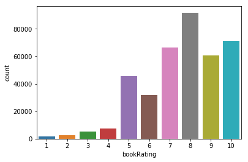

```python
# A countplot of bookRating indicates that higher ratings are more common amongst users and rating 8 has been rated highest number of times.
sns.countplot(data = rating_explicit, x='bookRating')
```

```python
rating_count = pd.DataFrame(ratings.groupby('ISBN')['bookRating'].count())
rating_count.sort_values('bookRating', ascending=False).head()
```

| ISBN | bookRating |
| --- | --- |
| 0971880107 | 2502 |
| 0316666343 | 1295 |
| 0385504209 | 883 |
| 0060928336 | 732 |
| 0312195516 | 723 |

```python
most_rated_books = pd.DataFrame(['0971880107', '0316666343', '0385504209', '0060928336', '0312195516'], index=np.arange(5), columns = ['ISBN'])
most_rated_books_summary = pd.merge(most_rated_books, books, on='ISBN')
most_rated_books_summary
```

|  | ISBN | bookTitle | bookAuthor | yearOfPublication | publisher |
| --- | --- | --- | --- | --- | --- |
| 0 | 0971880107 | Wild Animus | Rich Shapero | 2004 | Too Far |
| 1 | 0316666343 | The Lovely Bones: A Novel | Alice Sebold | 2002 | Little, Brown |
| 2 | 0385504209 | The Da Vinci Code | Dan Brown | 2003 | Doubleday |
| 3 | 0060928336 | Divine Secrets of the Ya-Ya Sisterhood: A Novel | Rebecca Wells | 1997 | Perennial |
| 4 | 0312195516 | The Red Tent (Bestselling Backlist) | Anita Diamant | 1998 | Picador USA |

```python
average_rating = pd.DataFrame(ratings.groupby('ISBN')['bookRating'].mean())
average_rating['ratingCount'] = pd.DataFrame(ratings.groupby('ISBN')['bookRating'].count())
average_rating.sort_values('ratingCount', ascending=False).head()
```

| ISBN | bookRating | ratingCount |
| --- | --- | --- |
| 0971880107 | 1.019584 | 2502 |
| 0316666343 | 4.468726 | 1295 |
| 0385504209 | 4.652322 | 883 |
| 0060928336 | 3.448087 | 732 |
| 0312195516 | 4.334716 | 723 |

### **Collaborative Filtering Based Recommendation Systems**

### For more accurate results only consider users who have rated atleast 100 books

```python
counts = rating_explicit['userID'].value_counts()
rating_explicit = rating_explicit[rating_explicit['userID'].isin(counts[counts >= 100].index)]
counts = rating_explicit['bookRating'].value_counts()
rating_explicit = rating_explicit[rating_explicit['bookRating'].isin(counts[counts >= 100].index)]
```

```python
# to show the NaN in the dataset
ratings_pivot = rating_explicit.pivot(index='userID', columns='ISBN' , values='bookRating')
userID = ratings_pivot.index
ISBN = ratings_pivot.columns
print(ratings_pivot.shape)
ratings_pivot.head()
```

```
(449, 66572)
```

| ISBN userID | 0000913154 | 0001046438 | 000104687X | 0001047213 | 0001047973 | 000104799X | 0001048082 | 0001053736 | 0001053744 | 0001055607 | ... | B000092Q0A | B00009EF82 | B00009NDAN | B0000DYXID | B0000T6KHI | B0000VZEJQ | B0000X8HIE | B00013AX9E | B0001I1KOG | B000234N3A |
| --- | --- | --- | --- | --- | --- | --- | --- | --- | --- | --- | --- | --- | --- | --- | --- | --- | --- | --- | --- | --- | --- |
| 2033 | NaN | NaN | NaN | NaN | NaN | NaN | NaN | NaN | NaN | NaN | ... | NaN | NaN | NaN | NaN | NaN | NaN | NaN | NaN | NaN | NaN |
| 2110 | NaN | NaN | NaN | NaN | NaN | NaN | NaN | NaN | NaN | NaN | ... | NaN | NaN | NaN | NaN | NaN | NaN | NaN | NaN | NaN | NaN |
| 2276 | NaN | NaN | NaN | NaN | NaN | NaN | NaN | NaN | NaN | NaN | ... | NaN | NaN | NaN | NaN | NaN | NaN | NaN | NaN | NaN | NaN |
| 4017 | NaN | NaN | NaN | NaN | NaN | NaN | NaN | NaN | NaN | NaN | ... | NaN | NaN | NaN | NaN | NaN | NaN | NaN | NaN | NaN | NaN |
| 4385 | NaN | NaN | NaN | NaN | NaN | NaN | NaN | NaN | NaN | NaN | ... | NaN | NaN | NaN | NaN | NaN | NaN | NaN | NaN | NaN | NaN |

5 rows × 66572 columns

```python
ratings['userID'].isna().sum()
```

```
0
```

```python
ratings['bookRating'].isna().sum()
```

```
0
```

### Generating ratings matrix from explicit ratings

#### Note: since NaNs cannot be handled by training algorithms, replace these by 0, which indicates absence of ratings

```python
r_df = rating_explicit.pivot(index='userID', columns='ISBN', values = 'bookRating').fillna(0)
r_df.head()
```

| ISBN userID | 0000913154 | 0001046438 | 000104687X | 0001047213 | 0001047973 | 000104799X | 0001048082 | 0001053736 | 0001053744 | 0001055607 | ... | B000092Q0A | B00009EF82 | B00009NDAN | B0000DYXID | B0000T6KHI | B0000VZEJQ | B0000X8HIE | B00013AX9E | B0001I1KOG | B000234N3A |
| --- | --- | --- | --- | --- | --- | --- | --- | --- | --- | --- | --- | --- | --- | --- | --- | --- | --- | --- | --- | --- | --- |
| 2033 | 0.0 | 0.0 | 0.0 | 0.0 | 0.0 | 0.0 | 0.0 | 0.0 | 0.0 | 0.0 | ... | 0.0 | 0.0 | 0.0 | 0.0 | 0.0 | 0.0 | 0.0 | 0.0 | 0.0 | 0.0 |
| 2110 | 0.0 | 0.0 | 0.0 | 0.0 | 0.0 | 0.0 | 0.0 | 0.0 | 0.0 | 0.0 | ... | 0.0 | 0.0 | 0.0 | 0.0 | 0.0 | 0.0 | 0.0 | 0.0 | 0.0 | 0.0 |
| 2276 | 0.0 | 0.0 | 0.0 | 0.0 | 0.0 | 0.0 | 0.0 | 0.0 | 0.0 | 0.0 | ... | 0.0 | 0.0 | 0.0 | 0.0 | 0.0 | 0.0 | 0.0 | 0.0 | 0.0 | 0.0 |
| 4017 | 0.0 | 0.0 | 0.0 | 0.0 | 0.0 | 0.0 | 0.0 | 0.0 | 0.0 | 0.0 | ... | 0.0 | 0.0 | 0.0 | 0.0 | 0.0 | 0.0 | 0.0 | 0.0 | 0.0 | 0.0 |
| 4385 | 0.0 | 0.0 | 0.0 | 0.0 | 0.0 | 0.0 | 0.0 | 0.0 | 0.0 | 0.0 | ... | 0.0 | 0.0 | 0.0 | 0.0 | 0.0 | 0.0 | 0.0 | 0.0 | 0.0 | 0.0 |

5 rows × 66572 columns

### Generate the predicted ratings using SVD with no.of singular values to be 50

```python
r_df = rating_explicit.pivot(index='userID', columns='ISBN', values = 'bookRating').fillna(0)
r_df.head()
```

| ISBN userID | 0000913154 | 0001046438 | 000104687X | 0001047213 | 0001047973 | 000104799X | 0001048082 | 0001053736 | 0001053744 | 0001055607 | ... | B000092Q0A | B00009EF82 | B00009NDAN | B0000DYXID | B0000T6KHI | B0000VZEJQ | B0000X8HIE | B00013AX9E | B0001I1KOG | B000234N3A |
| --- | --- | --- | --- | --- | --- | --- | --- | --- | --- | --- | --- | --- | --- | --- | --- | --- | --- | --- | --- | --- | --- |
| 2033 | 0.0 | 0.0 | 0.0 | 0.0 | 0.0 | 0.0 | 0.0 | 0.0 | 0.0 | 0.0 | ... | 0.0 | 0.0 | 0.0 | 0.0 | 0.0 | 0.0 | 0.0 | 0.0 | 0.0 | 0.0 |
| 2110 | 0.0 | 0.0 | 0.0 | 0.0 | 0.0 | 0.0 | 0.0 | 0.0 | 0.0 | 0.0 | ... | 0.0 | 0.0 | 0.0 | 0.0 | 0.0 | 0.0 | 0.0 | 0.0 | 0.0 | 0.0 |
| 2276 | 0.0 | 0.0 | 0.0 | 0.0 | 0.0 | 0.0 | 0.0 | 0.0 | 0.0 | 0.0 | ... | 0.0 | 0.0 | 0.0 | 0.0 | 0.0 | 0.0 | 0.0 | 0.0 | 0.0 | 0.0 |
| 4017 | 0.0 | 0.0 | 0.0 | 0.0 | 0.0 | 0.0 | 0.0 | 0.0 | 0.0 | 0.0 | ... | 0.0 | 0.0 | 0.0 | 0.0 | 0.0 | 0.0 | 0.0 | 0.0 | 0.0 | 0.0 |
| 4385 | 0.0 | 0.0 | 0.0 | 0.0 | 0.0 | 0.0 | 0.0 | 0.0 | 0.0 | 0.0 | ... | 0.0 | 0.0 | 0.0 | 0.0 | 0.0 | 0.0 | 0.0 | 0.0 | 0.0 | 0.0 |

5 rows × 66572 columns

```python
from scipy.sparse import csc_matrix
from scipy.sparse.linalg import svds
U, sigma, Vt = svds(r_df, k =50)
```

```python
print(U)
```

```
[[-0.0287257   0.00276858 -0.00163491 ...  0.00468381  0.00146285
   0.00115382]
 [-0.00316014  0.00280843 -0.00656488 ...  0.00106169  0.00106767
   0.00048237]
 [ 0.02266219  0.00362367  0.00392174 ...  0.00025662  0.00290815
   0.001983  ]
 ...
 [ 0.01809824 -0.00283048  0.01413323 ...  0.00053466  0.00421407
   0.00171786]
 [ 0.01331746 -0.00389798  0.00813826 ...  0.00109245  0.00485681
   0.00238477]
 [-0.00396598 -0.00564164  0.00528432 ...  0.00287071  0.00101021
   0.0006922 ]]
```

```python
print(sigma)
```

```
[147.92121613 149.3438051  150.07400599 152.20116297 152.87416391
 154.61308307 154.80093432 155.95760177 158.05646578 159.21079484
 159.81670657 162.01963916 162.77851768 163.33054635 166.02489324
 166.8162391  168.04972004 170.77485167 171.01325686 173.29428498
 174.57624968 176.65724713 178.61913749 180.29517222 182.25079063
 184.10706957 187.61687534 189.75276623 190.96966388 195.14643609
 199.83133018 201.70083339 202.18713912 203.48697581 207.26449173
 209.92986988 213.23598777 216.88280493 224.26954726 231.66186197
 235.67095629 249.9581775  252.02866425 261.24756904 267.98197504
 281.0120779  293.69539562 379.58327277 634.72875357 680.30978318]
```

```python
print(Vt)
```

```
[[-3.92054115e-04 -1.12885905e-03 -7.52572700e-04 ...  1.21259171e-04
   1.40728079e-03 -9.39266652e-04]
 [ 1.83812046e-04  8.04527056e-05  5.36351371e-05 ... -2.03616968e-05
  -1.13338633e-05  8.89199391e-05]
 [-6.45220069e-04 -1.81903383e-04 -1.21268922e-04 ...  6.52663017e-05
   5.77432315e-05 -2.03720513e-03]
 ...
 [ 9.70964741e-05  8.85065735e-05  5.90043823e-05 ...  9.93843072e-07
  -1.57012541e-06  1.95172262e-04]
 [ 1.24358727e-04  1.40102246e-04  9.34014973e-05 ...  6.42409858e-06
   3.12147472e-05  1.36580955e-04]
 [ 5.27949012e-05  4.51140032e-05  3.00760021e-05 ...  1.98299389e-06
   9.61038459e-06  4.83048138e-05]]
```

### Take a particular user_id

### Lets find the recommendations for user with id `2110`

#### Note: Execute the below cells to get the variables loaded

```python
userID = 2110
```

```python
user_id = 2 #2nd row in ratings matrix and predicted matrix
```

### Get the predicted ratings for userID `2110` and sort them in descending order

```python
sigma = np.diag(sigma)
```

```python
sigma.shape
```

```
(50, 50)
```

```python
R = r_df.as_matrix()
user_ratings_mean = np.mean(R, axis = 1)
R_demeaned = R - user_ratings_mean.reshape(-1, 1)
```

```python
# Prediction for all users
```

```python
all_user_predicted_ratings = np.dot(np.dot(U, sigma), Vt) + user_ratings_mean.reshape(-1, 1)
```

```python
preds_df = pd.DataFrame(all_user_predicted_ratings, columns = r_df.columns)
preds_df.head()
```

| ISBN | 0000913154 | 0001046438 | 000104687X | 0001047213 | 0001047973 | 000104799X | 0001048082 | 0001053736 | 0001053744 | 0001055607 | ... | B000092Q0A | B00009EF82 | B00009NDAN | B0000DYXID | B0000T6KHI | B0000VZEJQ | B0000X8HIE | B00013AX9E | B0001I1KOG | B000234N3A |
| --- | --- | --- | --- | --- | --- | --- | --- | --- | --- | --- | --- | --- | --- | --- | --- | --- | --- | --- | --- | --- | --- |
| 0 | 0.042240 | 0.014753 | 0.015468 | 0.014753 | 0.014753 | 0.019870 | 0.012979 | 0.023934 | 0.023934 | 0.029215 | ... | 0.017079 | 0.017125 | 0.058980 | 0.000095 | -0.063129 | 0.021645 | 0.045213 | 0.017019 | 0.015206 | 0.084402 |
| 1 | 0.002801 | 0.009144 | 0.010367 | 0.009144 | 0.009144 | 0.013888 | 0.014253 | 0.009313 | 0.009313 | 0.014426 | ... | 0.012450 | 0.013216 | 0.020955 | 0.013917 | -0.016411 | 0.013812 | 0.015176 | 0.012571 | 0.012842 | -0.000246 |
| 2 | 0.009566 | 0.009163 | 0.014316 | 0.009163 | 0.009163 | 0.031901 | 0.010587 | 0.036561 | 0.036561 | 0.036416 | ... | 0.024165 | 0.026527 | 0.072602 | 0.030357 | 0.142479 | 0.031565 | 0.027739 | 0.024316 | 0.033629 | -0.033072 |
| 3 | -0.000770 | 0.056331 | 0.044464 | 0.056331 | 0.056331 | 0.051037 | 0.044944 | 0.019677 | 0.019677 | 0.088308 | ... | 0.023701 | 0.030641 | 0.106978 | 0.011912 | 0.036883 | 0.049577 | 0.020605 | 0.022710 | 0.051930 | -0.025934 |
| 4 | 0.033082 | 0.023039 | 0.025694 | 0.023039 | 0.023039 | 0.033951 | 0.034061 | 0.031235 | 0.031235 | 0.037084 | ... | 0.033124 | 0.032601 | 0.018823 | 0.040424 | 0.704463 | 0.033595 | 0.022775 | 0.032417 | 0.035922 | 0.078777 |

5 rows × 66572 columns

```python
# Prediction for 2110 user
```

```python
specific_user_predicted_ratings = np.dot(np.dot(U, sigma), Vt)
preds_df1 = pd.DataFrame(specific_user_predicted_ratings, columns = r_df.columns, index= r_df.index)
```

```python
preds_df1.head()
```

| ISBN userID | 0000913154 | 0001046438 | 000104687X | 0001047213 | 0001047973 | 000104799X | 0001048082 | 0001053736 | 0001053744 | 0001055607 | ... | B000092Q0A | B00009EF82 | B00009NDAN | B0000DYXID | B0000T6KHI | B0000VZEJQ | B0000X8HIE | B00013AX9E | B0001I1KOG | B000234N3A |
| --- | --- | --- | --- | --- | --- | --- | --- | --- | --- | --- | --- | --- | --- | --- | --- | --- | --- | --- | --- | --- | --- |
| 2033 | 0.025341 | -0.002146 | -0.001431 | -0.002146 | -0.002146 | 0.002971 | -0.003920 | 0.007035 | 0.007035 | 0.012316 | ... | 0.000180 | 0.000226 | 0.042081 | -0.016804 | -0.080028 | 0.004746 | 0.028314 | 0.000120 | -0.001693 | 0.067503 |
| 2110 | -0.010012 | -0.003669 | -0.002446 | -0.003669 | -0.003669 | 0.001075 | 0.001440 | -0.003500 | -0.003500 | 0.001612 | ... | -0.000363 | 0.000403 | 0.008142 | 0.001104 | -0.029224 | 0.000999 | 0.002363 | -0.000242 | 0.000029 | -0.013059 |
| 2276 | -0.015054 | -0.015457 | -0.010304 | -0.015457 | -0.015457 | 0.007281 | -0.014033 | 0.011941 | 0.011941 | 0.011796 | ... | -0.000455 | 0.001907 | 0.047982 | 0.005737 | 0.117859 | 0.006945 | 0.003119 | -0.000304 | 0.009009 | -0.057692 |
| 4017 | -0.021499 | 0.035602 | 0.023735 | 0.035602 | 0.035602 | 0.030307 | 0.024215 | -0.001053 | -0.001053 | 0.067579 | ... | 0.002971 | 0.009912 | 0.086248 | -0.008818 | 0.016154 | 0.028848 | -0.000125 | 0.001981 | 0.031201 | -0.046664 |
| 4385 | 0.002077 | -0.007965 | -0.005310 | -0.007965 | -0.007965 | 0.002947 | 0.003057 | 0.000231 | 0.000231 | 0.006080 | ... | 0.002120 | 0.001597 | -0.012181 | 0.009420 | 0.673459 | 0.002591 | -0.008229 | 0.001413 | 0.004918 | 0.047773 |

5 rows × 66572 columns

```python
sort_pred = preds_df1.loc[2110,:].sort_values(ascending = False)
```

```python
sort_pred
```

```
ISBN
059035342X    0.682444
0345370775    0.368946
0345384911    0.333624
043935806X    0.333209
044021145X    0.329336
0451151259    0.313295
0439139597    0.305088
0439064872    0.290587
0380759497    0.278563
0345353145    0.250941
0451167317    0.249254
0439136369    0.242676
0618002235    0.239957
0880389117    0.239552
```

[output cut: 48 more lines]

### Create a dataframe with name `user_data` containing userID `2110` explicitly interacted books

```python
user_data = rating_explicit[rating_explicit['userID'] == 2110]
```

```python
user_data.head()
```

|  | userID | ISBN | bookRating |
| --- | --- | --- | --- |
| 14448 | 2110 | 0060987529 | 7 |
| 14449 | 2110 | 0064472779 | 8 |
| 14450 | 2110 | 0140022651 | 10 |
| 14452 | 2110 | 0142302163 | 8 |
| 14453 | 2110 | 0151008116 | 5 |

```python
user_data.shape
```

```
(103, 3)
```

### Combine the user_data and and corresponding book data(`book_data`) in a single dataframe with name `user_full_info`

```python
book_data = books[books.ISBN.isin(user_data.ISBN)]
```

```python
book_data.head()
```

|  | ISBN | bookTitle | bookAuthor | yearOfPublication | publisher |
| --- | --- | --- | --- | --- | --- |
| 246 | 0151008116 | Life of Pi | Yann Martel | 2002 | Harcourt |
| 904 | 015216250X | So You Want to Be a Wizard: The First Book in ... | Diane Duane | 2001 | Magic Carpet Books |
| 1000 | 0064472779 | All-American Girl | Meg Cabot | 2003 | HarperTrophy |
| 1302 | 0345307674 | Return of the Jedi (Star Wars) | James Kahn | 1983 | Del Rey Books |
| 1472 | 0671527215 | Hitchhikers's Guide to the Galaxy | Douglas Adams | 1984 | Pocket |

```python
book_data.shape
```

```
(103, 5)
```

```python
user_full_info=pd.merge(user_data,book_data)
```

```python
user_full_info.head()
```

|  | userID | ISBN | bookRating | bookTitle | bookAuthor | yearOfPublication | publisher |
| --- | --- | --- | --- | --- | --- | --- | --- |
| 0 | 2110 | 0060987529 | 7 | Confessions of an Ugly Stepsister : A Novel | Gregory Maguire | 2000 | Regan Books |
| 1 | 2110 | 0064472779 | 8 | All-American Girl | Meg Cabot | 2003 | HarperTrophy |
| 2 | 2110 | 0140022651 | 10 | Journey to the Center of the Earth | Jules Verne | 1965 | Penguin Books |
| 3 | 2110 | 0142302163 | 8 | The Ghost Sitter | Peni R. Griffin | 2002 | Puffin Books |
| 4 | 2110 | 0151008116 | 5 | Life of Pi | Yann Martel | 2002 | Harcourt |

```python
books_not_pred = books[~books['ISBN'].isin(user_full_info['ISBN'])]
```

```python
books_not_pred.head()
```

|  | ISBN | bookTitle | bookAuthor | yearOfPublication | publisher |
| --- | --- | --- | --- | --- | --- |
| 0 | 0195153448 | Classical Mythology | Mark P. O. Morford | 2002 | Oxford University Press |
| 1 | 0002005018 | Clara Callan | Richard Bruce Wright | 2001 | HarperFlamingo Canada |
| 2 | 0060973129 | Decision in Normandy | Carlo D'Este | 1991 | HarperPerennial |
| 3 | 0374157065 | Flu: The Story of the Great Influenza Pandemic... | Gina Bari Kolata | 1999 | Farrar Straus Giroux |
| 4 | 0393045218 | The Mummies of Urumchi | E. J. W. Barber | 1999 | W. W. Norton &amp; Company |

```python
predict_recom_for_user = books_not_pred.merge(pd.DataFrame(sort_pred).reset_index())
```

```python
print ('Top 10 recommendations for the user from the books that are not predicted are listed below' )
predict_recom_for_user.head()
```

```
Top 10 recommendations for the user from the books that are not predicted are listed below
```

|  | ISBN | bookTitle | bookAuthor | yearOfPublication | publisher | 2110 |
| --- | --- | --- | --- | --- | --- | --- |
| 0 | 0002005018 | Clara Callan | Richard Bruce Wright | 2001 | HarperFlamingo Canada | 0.000883 |
| 1 | 0374157065 | Flu: The Story of the Great Influenza Pandemic... | Gina Bari Kolata | 1999 | Farrar Straus Giroux | -0.001017 |
| 2 | 0399135782 | The Kitchen God's Wife | Amy Tan | 1991 | Putnam Pub Group | 0.002769 |
| 3 | 0425176428 | What If?: The World's Foremost Military Histor... | Robert Cowley | 2000 | Berkley Publishing Group | 0.001838 |
| 4 | 0671870432 | PLEADING GUILTY | Scott Turow | 1993 | Audioworks | 0.000883 |